# 19 - Time series analysis

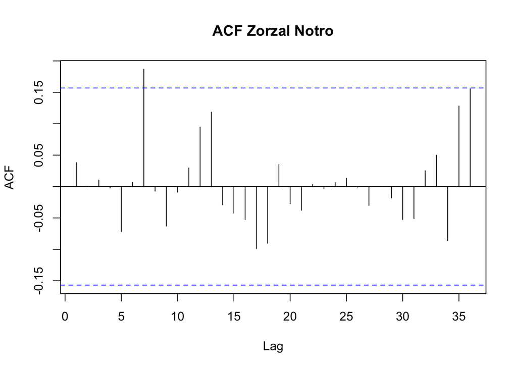

```r
acf(as.vector(turnot),lag.max=36, main="ACF Zorzal Notro")
```

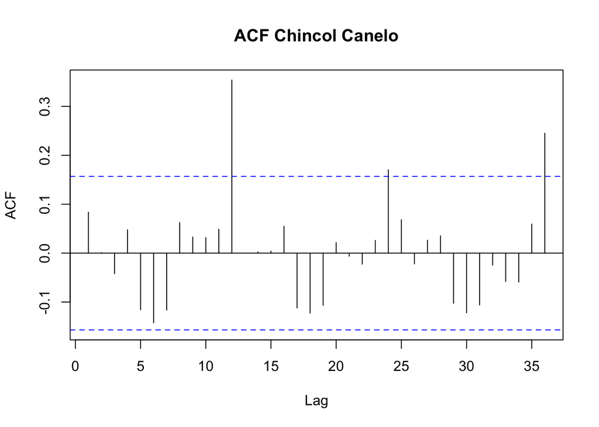

```r
acf(as.vector(zoncan),lag.max=36, main="ACF Chincol Canelo")
```

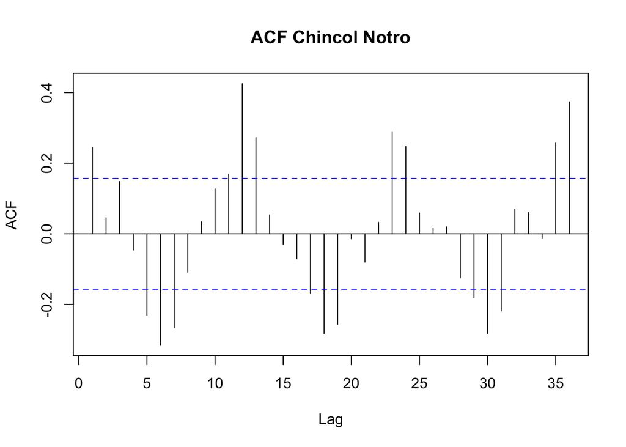

```r
acf(as.vector(zonnot),lag.max=36, main="ACF Chincol Notro")
```

It’s common to find regular “waves” of autocorrelation, as they are given by seasonality. This analysis is useful to understand the temporal variation in any phenomenon that we are studying!

## Decomposing time series data

This is my favorite part! We can decompose a time series data into four elements: the data itself, the seasonal variation, the trend, and the remainder (error). We also can plot the variation within each month across years, and annual variation across sampling years. We will use only two species (one resident and one migratory) as an example here:

```r
#Rayadito-Canelo
decompose(aphcan)
```

```
## $x
##             Jan        Feb        Mar        Apr        May        Jun
## 2003  7.0850202  2.5248275  3.9407314  5.1695616  2.6586317  8.8113490
## 2004  6.5971764  4.7471171  1.9413036  5.5741360  3.9841503  3.0158028
## 2005  2.3619220  4.0345014  2.7329374  6.2751660  7.4578334  6.9220120
## 2006 11.1505593  9.2762739 14.7637795 12.7519612 13.0383958  4.5471080
## 2007  0.9587728  0.0000000  7.8485688  4.7728900  1.8450184 10.0967040
## 2008  7.8895464  7.5322474  5.3806044  5.7974936  2.9285435  1.9599068
## 2009  1.9656664  7.6736964  8.2051282  5.6410256  7.6923077 10.7599055
## 2010  2.2624434  5.4240631  9.0905156 10.1382489  6.3572791 12.6047050
## 2011  5.6980057  5.8496636  4.0518639  4.1907245  2.8490028  3.3238367
## 2012  7.3902705  6.3398140 12.1794872  3.8461538 11.5384615  5.5555556
## 2013  1.3603468  4.3272413  5.7354926  3.6521342  3.8948393  2.7195027
## 2014  2.1680687  2.9749256  5.4439545  3.1730203  3.6505867  3.2796661
## 2015  4.7520048  5.5660692  6.6312997  6.0798308  3.1080031  0.8140008
```

[output cut: 114 more lines]

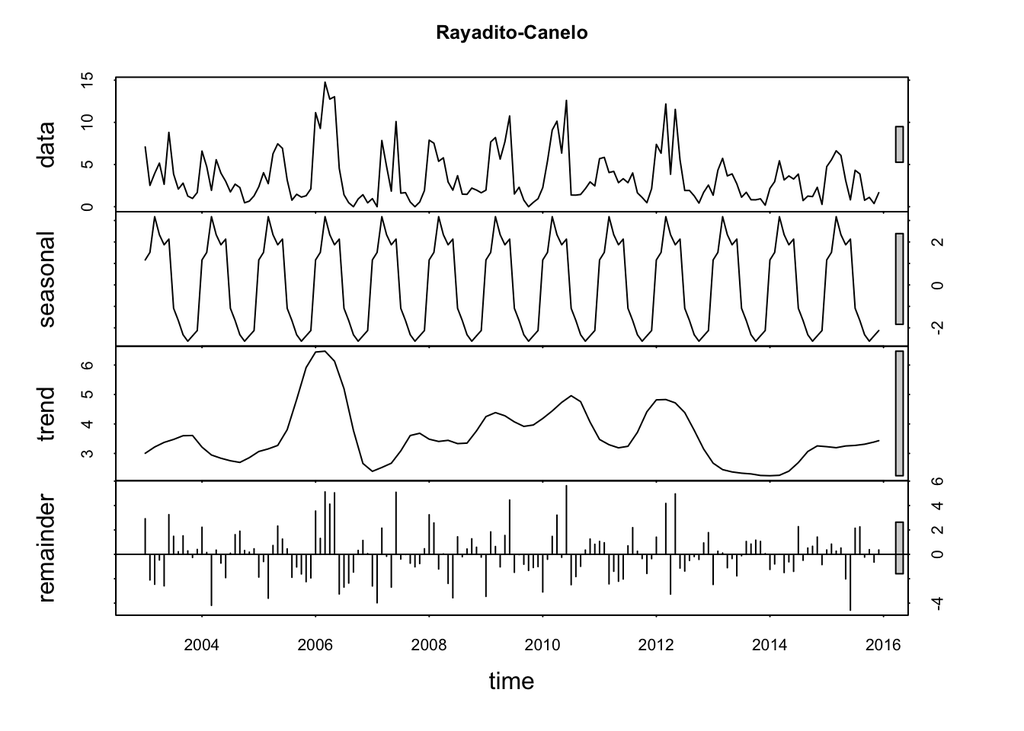

```r
fit.aphcan<-stl(aphcan, "periodic")
plot(fit.aphcan, main="Rayadito-Canelo")
```

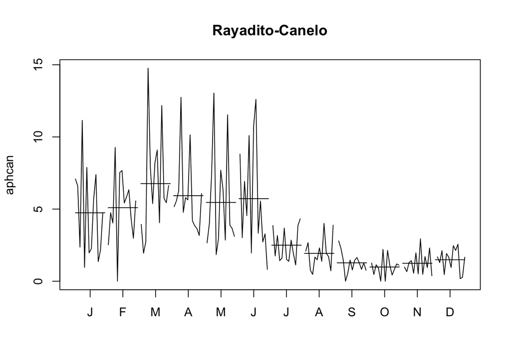

```r
monthplot(aphcan, main="Rayadito-Canelo")
```

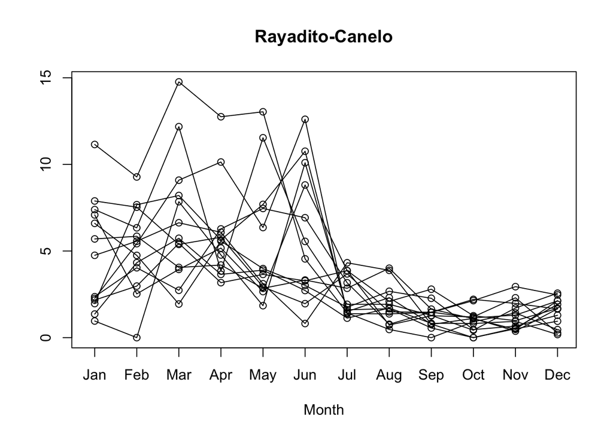

```r
seasonplot(aphcan, main="Rayadito-Canelo")
```

```r
##
#Rayadito-Notro
decompose(aphnot)
```

```
## $x
##             Jan        Feb        Mar        Apr        May        Jun
## 2003  6.1050061  1.0229133  1.8743440  2.4238429  0.0000000  0.8841733
## 2004  1.2498334  1.3792089  3.0971578  2.5996309  1.1214911  2.2024168
## 2005  5.4695021  0.7735627  0.0000000  6.2743130 10.7953122  2.6809939
## 2006  1.2797477  1.2501719  5.7850636  7.6086130  2.9871382  1.4792899
## 2007  1.0668943  0.0000000  4.8076923 12.9152245 18.0045943  0.0000000
## 2008  0.7396450  1.5110610  2.9077563  3.2573054  4.9162597  7.2663388
## 2009  1.4827751  3.6641669  7.1794872  7.1794872  5.3846154  4.5969966
## 2010  2.5655279  2.6361575  0.0000000  2.1367521  6.1253355  1.6025641
## 2011  0.0000000  0.6759497  6.8332683  0.9438414  5.1943146  3.7986705
## 2012  1.5172205  0.9506736 17.9487179  4.7008547  7.7787381  9.8181508
## 2013  0.0000000  0.3406087  1.6764058  2.7720028  2.3310023  0.0000000
## 2014  0.3448434  0.2249213  2.9239766  2.5471218  1.4652015  0.8212428
## 2015  0.0000000  0.7692308  0.5656109  0.0000000  3.1185031  0.8867213
```

[output cut: 114 more lines]

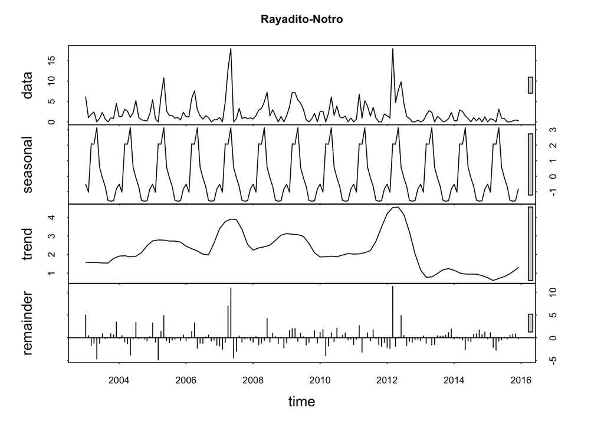

```r
fit.aphnot<-stl(aphnot, "periodic")
plot(fit.aphnot, main="Rayadito-Notro")
```

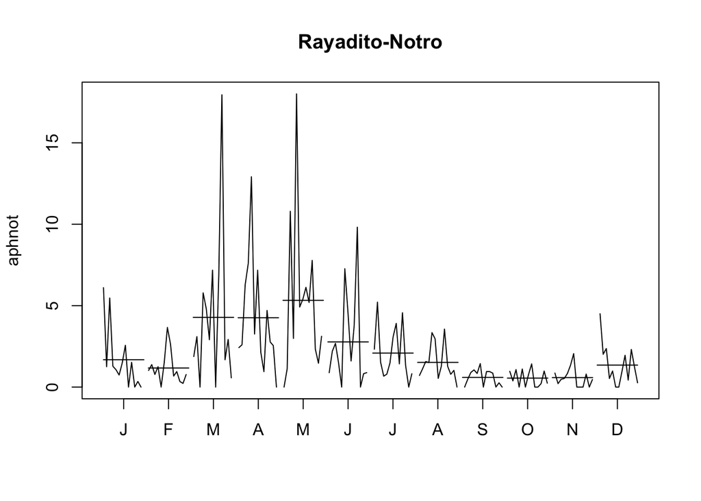

```r
monthplot(aphnot, main="Rayadito-Notro")
```

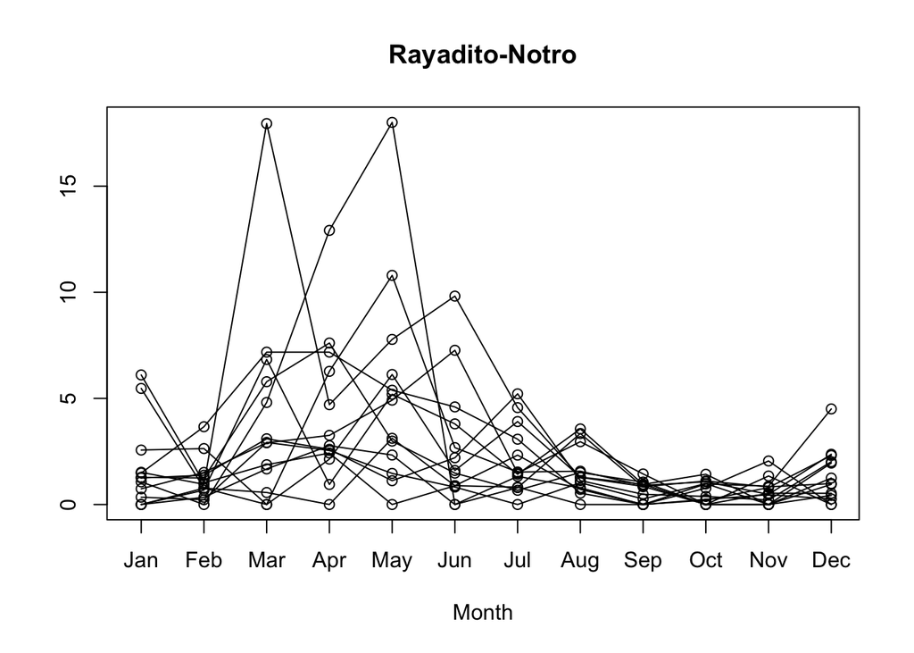

```r
seasonplot(aphnot, main="Rayadito-Notro")
```

```r
##
#Chincol-Canelo
decompose(zoncan)
```

```
## $x
##             Jan        Feb        Mar        Apr        May        Jun
## 2003 1.01214575 0.84160916 0.00000000 0.00000000 0.00000000 0.00000000
## 2004 1.64929410 0.00000000 0.00000000 0.00000000 0.00000000 0.00000000
## 2005 0.23619220 0.21234218 0.00000000 0.00000000 0.00000000 0.00000000
## 2006 5.35226847 0.88345466 0.00000000 0.00000000 0.00000000 0.00000000
## 2007 3.35570470 0.00000000 0.00000000 0.00000000 0.00000000 0.00000000
## 2008 1.47928994 0.00000000 0.00000000 0.00000000 0.00000000 0.00000000
## 2009 0.00000000 0.45139390 0.00000000 0.00000000 0.00000000 0.00000000
## 2010 0.00000000 0.00000000 0.00000000 0.00000000 0.00000000 0.00000000
## 2011 2.37416904 0.00000000 0.00000000 0.00000000 0.00000000 0.00000000
## 2012 1.92789667 0.00000000 0.00000000 0.00000000 0.00000000 0.00000000
## 2013 0.00000000 0.50908721 0.00000000 0.00000000 0.00000000 0.00000000
## 2014 0.08672275 0.00000000 0.00000000 0.00000000 0.00000000 0.00000000
## 2015 4.45500446 0.55660692 0.00000000 0.00000000 0.00000000 0.00000000
```

[output cut: 128 more lines]

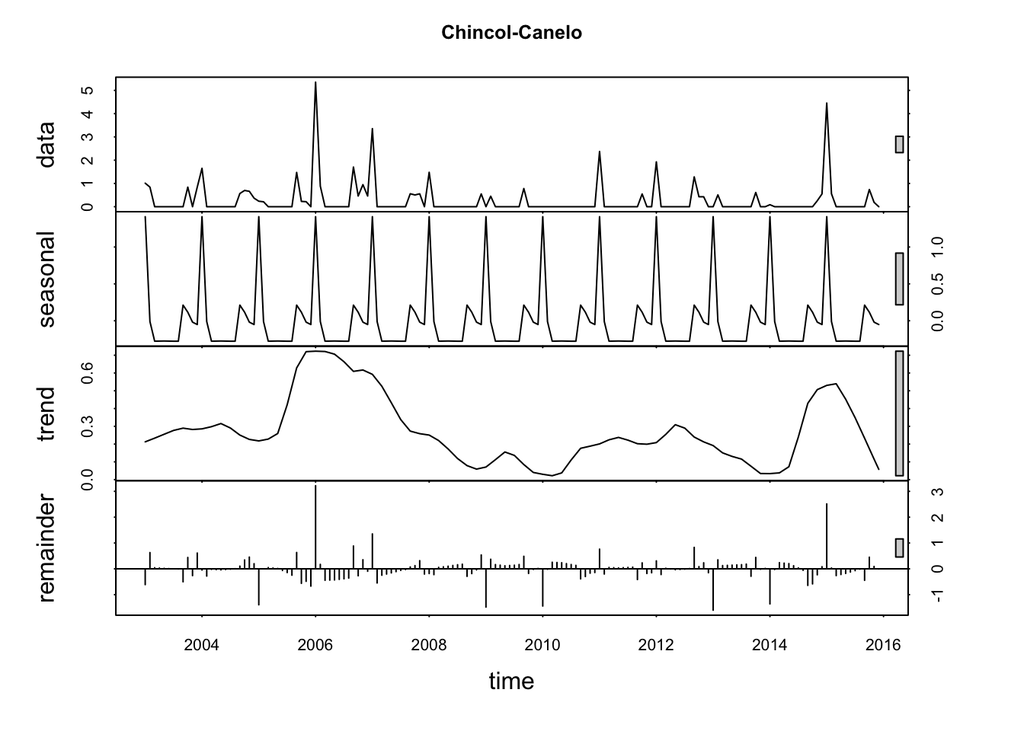

```r
fit.zoncan<-stl(zoncan, "periodic")
plot(fit.zoncan, main="Chincol-Canelo")
```

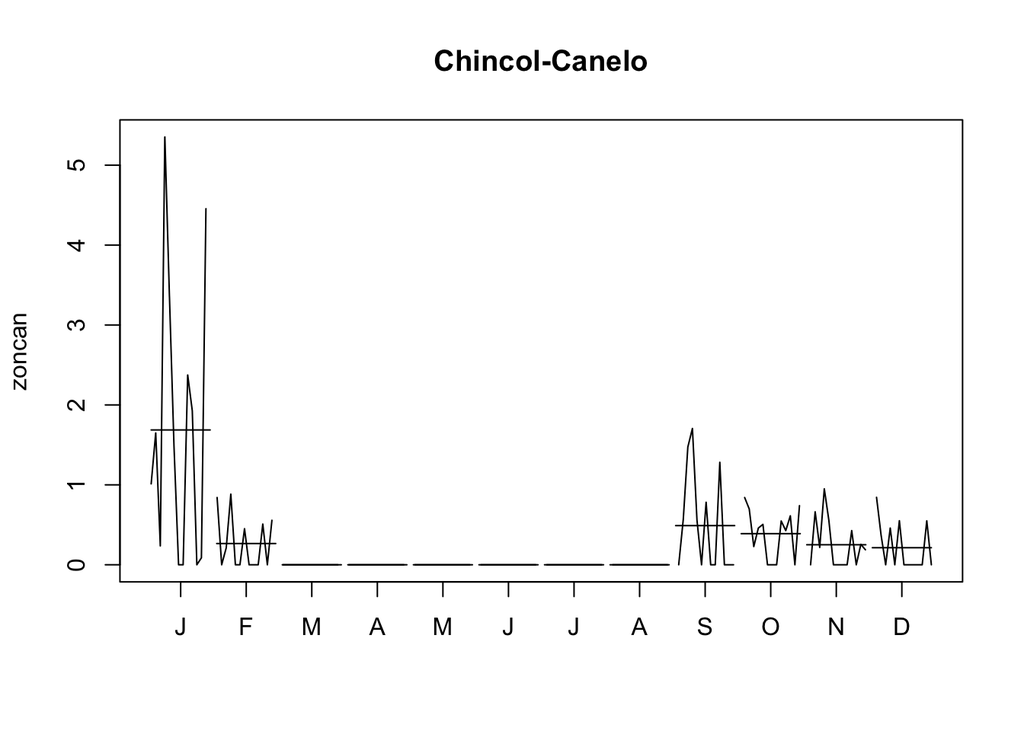

```r
monthplot(zoncan, main="Chincol-Canelo")
```

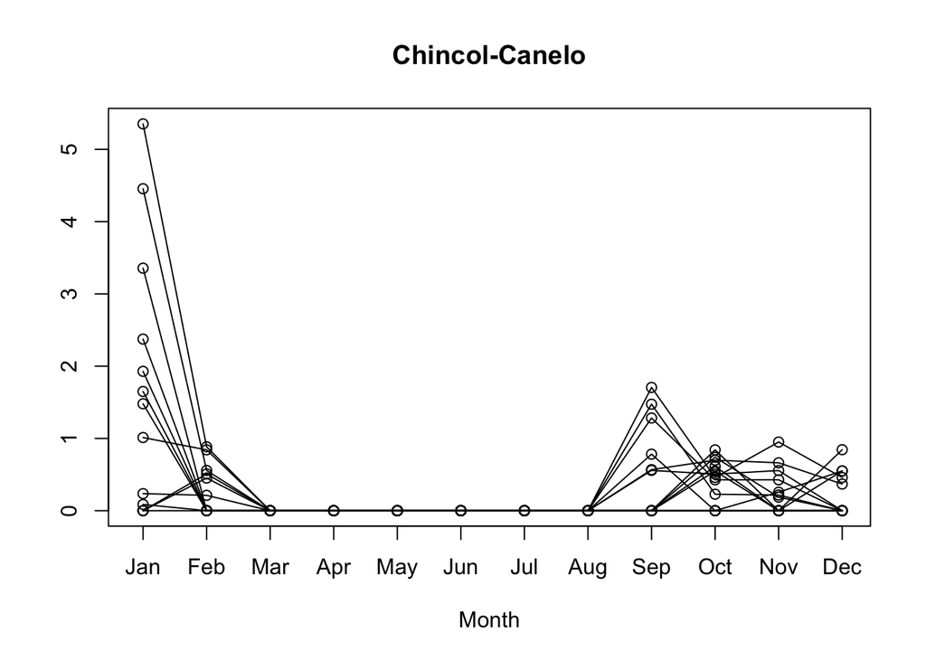

```r
seasonplot(zoncan, main="Chincol-Canelo")
```

```r
##
#Chincol-Notro
decompose(zonnot)
```

```
## $x
##            Jan       Feb       Mar       Apr       May       Jun       Jul
## 2003 0.0000000 0.0000000 0.6247813 0.0000000 0.0000000 0.0000000 0.0000000
## 2004 0.0000000 0.0000000 0.0000000 0.0000000 0.0000000 0.0000000 0.0000000
## 2005 1.0939004 0.5157085 0.0000000 0.0000000 0.0000000 0.0000000 0.0000000
## 2006 0.2559495 2.1878008 0.0000000 0.0000000 0.0000000 0.0000000 0.0000000
## 2007 1.6003414 0.5341880 0.0000000 0.0000000 0.0000000 0.0000000 0.0000000
## 2008 2.9585799 0.0000000 0.0000000 0.0000000 0.0000000 0.0000000 0.0000000
## 2009 0.9885167 0.7328334 0.0000000 0.0000000 0.0000000 0.0000000 0.0000000
## 2010 0.0000000 0.4393596 0.0000000 0.0000000 0.0000000 0.0000000 0.0000000
## 2011 2.7870680 0.0000000 0.3253937 0.0000000 0.0000000 0.0000000 0.0000000
## 2012 2.5287008 1.0864841 0.0000000 0.0000000 0.0000000 0.0000000 0.0000000
## 2013 0.1451817 0.0000000 0.0000000 0.0000000 0.0000000 0.0000000 0.0000000
## 2014 0.4597913 0.6747638 0.0000000 0.0000000 0.0000000 0.0000000 0.0000000
## 2015 0.9230769 1.1538462 0.0000000 0.0000000 0.0000000 0.0000000 0.0000000
```

[output cut: 128 more lines]

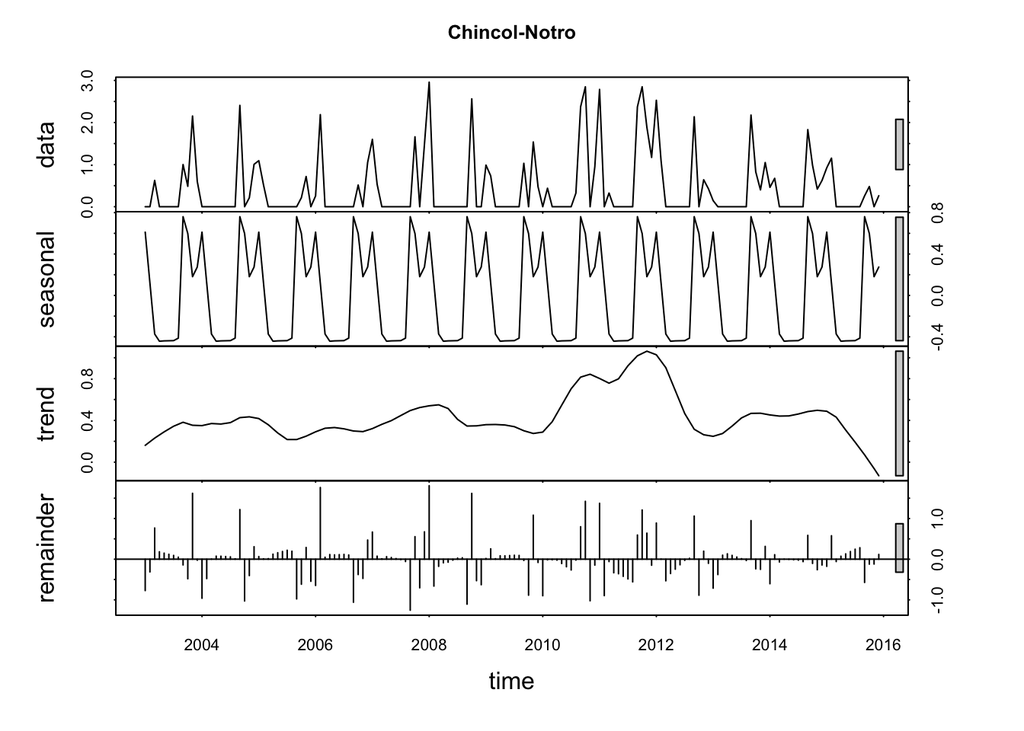

```r
fit.zonnot<-stl(zonnot, "periodic")
plot(fit.zonnot, main="Chincol-Notro")
```

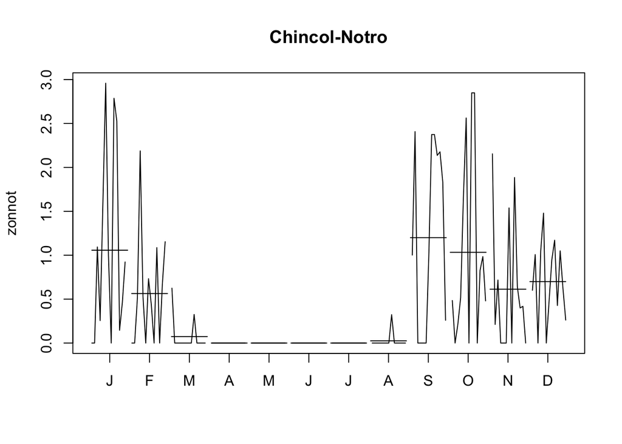

```r
monthplot(zonnot, main="Chincol-Notro")
```

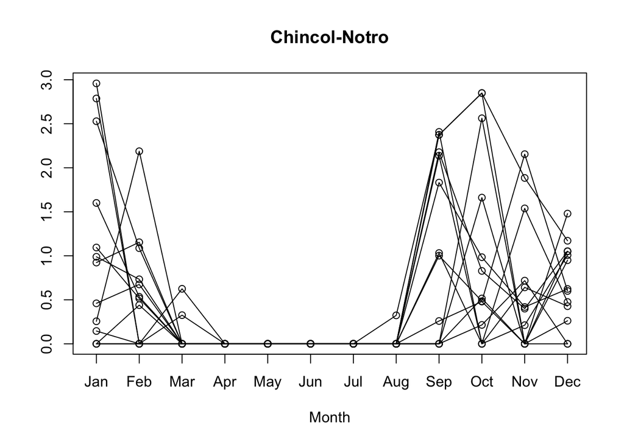

```r
seasonplot(zonnot, main="Chincol-Notro")
```

Very useful information indeed, with a bunch of applications for population ecology, conservation biology, wildlife management, etc.

### Cross-correlation functions

The cross-correlation functions (CCF) allows us to examine the variation of one variable in function of other. In the case of the example, how the abundances of two bird species vary in time or the same species in two habitats, let’s take a look on a couple of examples:

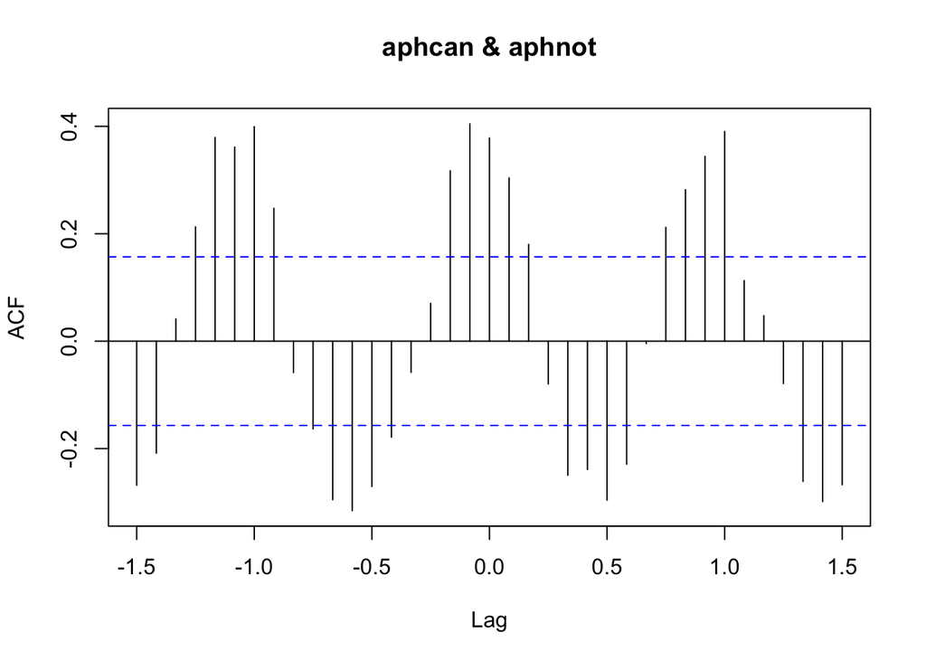

```r
ccf(aphcan, aphnot)
```

```r
var.test(aphcan, aphnot)
```

```
##
##  F test to compare two variances
##
## data:  aphcan and aphnot
## F = 1.152, num df = 155, denom df = 155, p-value = 0.3794
## alternative hypothesis: true ratio of variances is not equal to 1
## 95 percent confidence interval:
##  0.8398614 1.5801441
## sample estimates:
## ratio of variances
##           1.151999
```

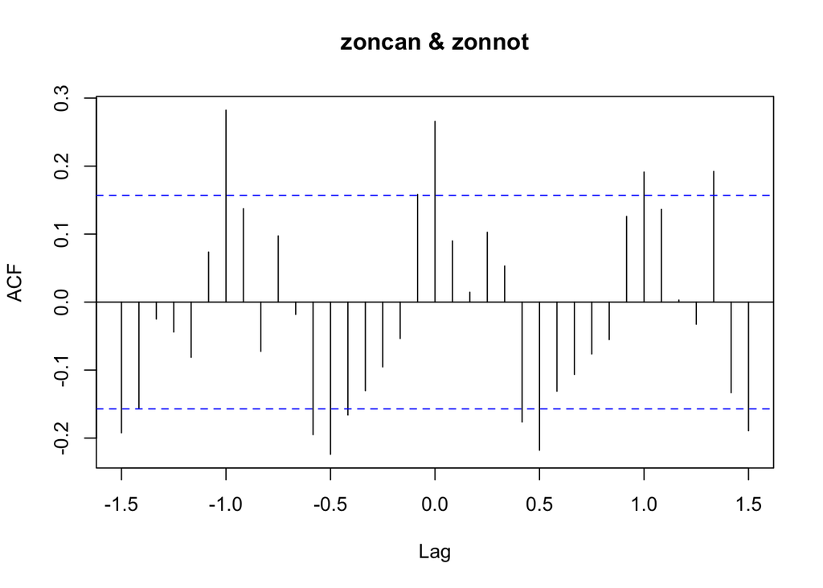

```r
ccf(zoncan, zonnot)
```

```r
var.test(zoncan, zonnot)
```

```
##
##  F test to compare two variances
##
## data:  zoncan and zonnot
## F = 0.90258, num df = 155, denom df = 155, p-value = 0.5242
## alternative hypothesis: true ratio of variances is not equal to 1
## 95 percent confidence interval:
##  0.6580267 1.2380340
## sample estimates:
## ratio of variances
##          0.9025848
```

## ARIMA models

Autoregressive integrated moving average (aka ARIMA) are intended to be used with time series data as they account for seasonality and temporal autocorrelation. ARIMA models are powerful tools for understanding patterns in time series data and making forecasts.

### Understanding ARIMA Components

ARIMA models can be decomposed into three main components, denoted as **ARIMA(p, d, q)(P, D, Q)[s]**:

**Non-seasonal components:**

- **AR (p) - Autoregressive:** Uses past values to predict current value (p = order)
- **I (d) - Integrated:** Differencing to make the series stationary (d = times differenced)
- **MA (q) - Moving Average:** Uses past forecast errors (q = order)

**Seasonal components (for seasonal data like our monthly bird counts):**

- **P:** Seasonal autoregressive order
- **D:** Seasonal differencing order
- **Q:** Seasonal moving average order
- **s:** Seasonal period (12 for monthly data)

*Please note that non-seasonal components and denoted in lowercase letter and seasonal components are denoted in uppercase letters*

### What Does Each Component Mean?

**ARIMA COMPONENT INTERPRETATION**

AR (AutoRegressive) - p parameter:

- How many past observations influence the current one?
- p=1: Today’s value depends on yesterday’s value
- p=2: Today depends on yesterday AND the day before
- Example: If birds were abundant last month, they’ll be abundant this month

I (Integrated) - d parameter:

- How many times do we need to difference the data to make it stationary?
- d=0: Data is already stationary (no trend)
- d=1: Remove linear trend by differencing once
- d=2: Remove quadratic trend (rare)
- Example: Remove long-term population increase/decrease

MA (Moving Average) - q parameter:

- How many past forecast errors influence the current value?
- q=1: Current value depends on the previous forecast error
- q=2: Depends on last two forecast errors
- Example: If we overestimated last month, we adjust this month

Seasonal components (P, D, Q):

- Same idea but for seasonal patterns
- Period s=12 for monthly data (yearly cycle)
- Example: April’s abundance relates to last April’s abundance

### Determining ARIMA Order: A Step-by-Step Guide

Before fitting ARIMA models, we should examine our data to determine appropriate orders:

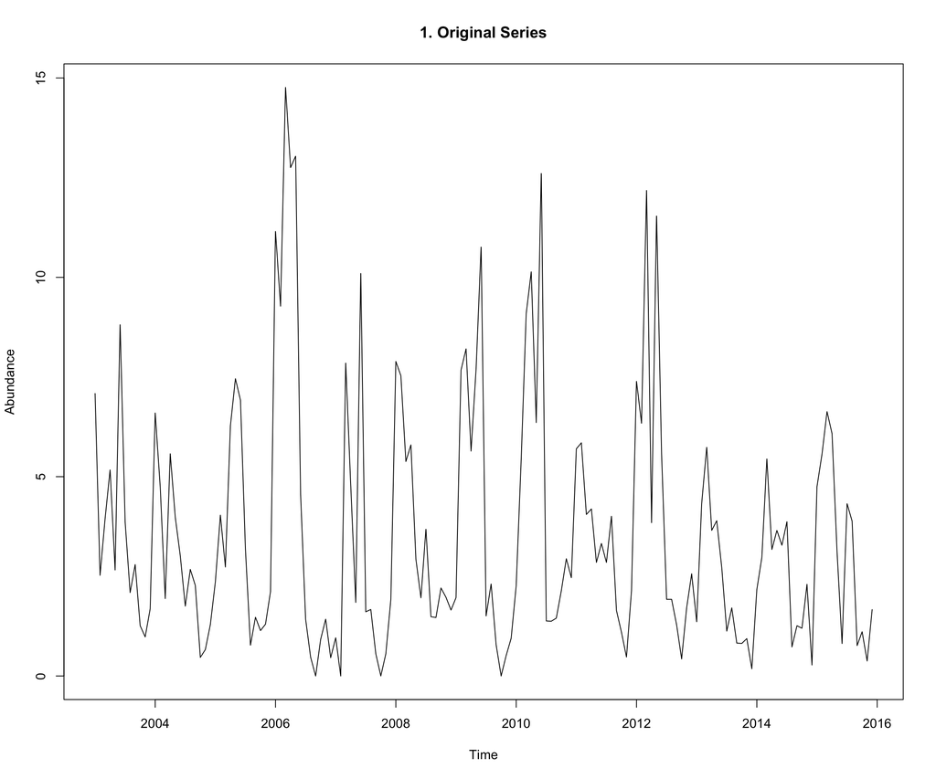

```r
# Let's focus on Rayadito-Canelo as an example
# 1. Original series
plot(aphcan, main="1. Original Series", ylab="Abundance")
```

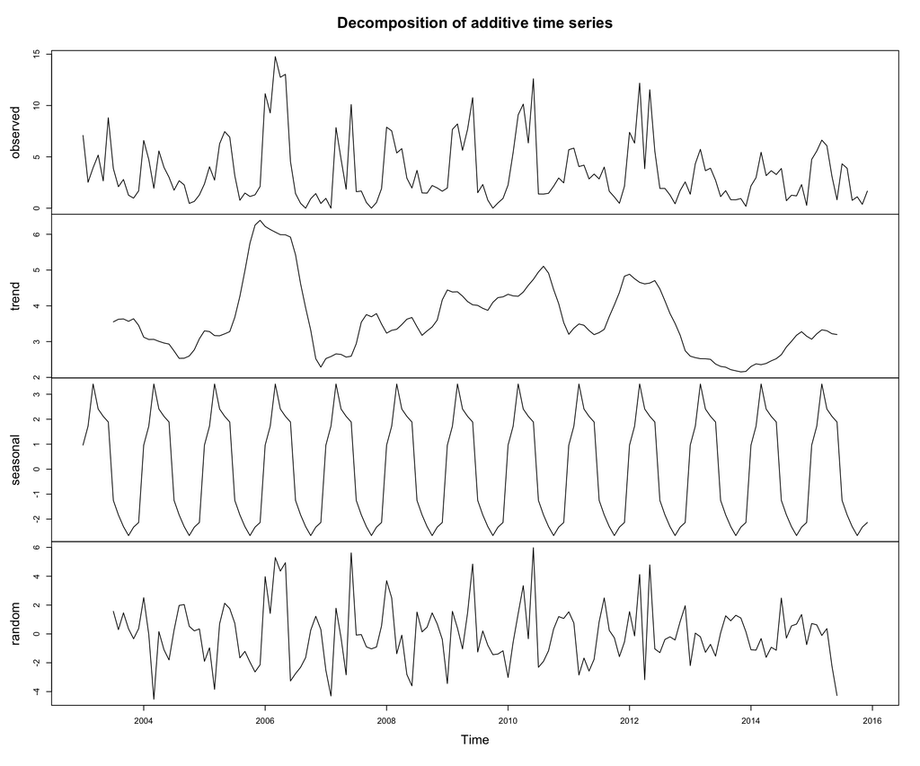

```r
# 2. Check for trend and seasonality
plot(decompose(aphcan))
```

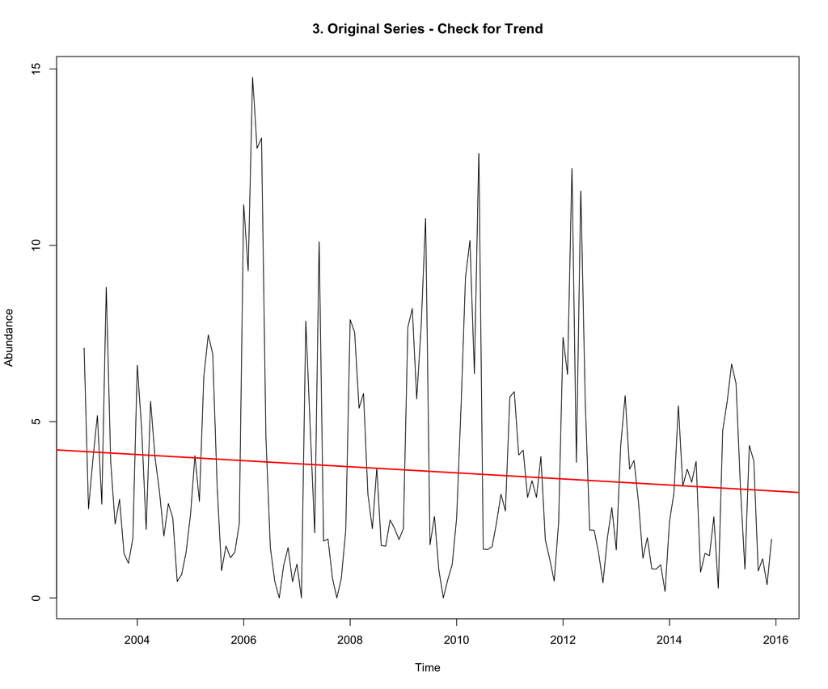

```r
# 3. Check stationarity - does it need differencing?
plot(aphcan, main="3. Original Series - Check for Trend", ylab="Abundance")
abline(reg=lm(aphcan~time(aphcan)), col="red", lwd=2)
```

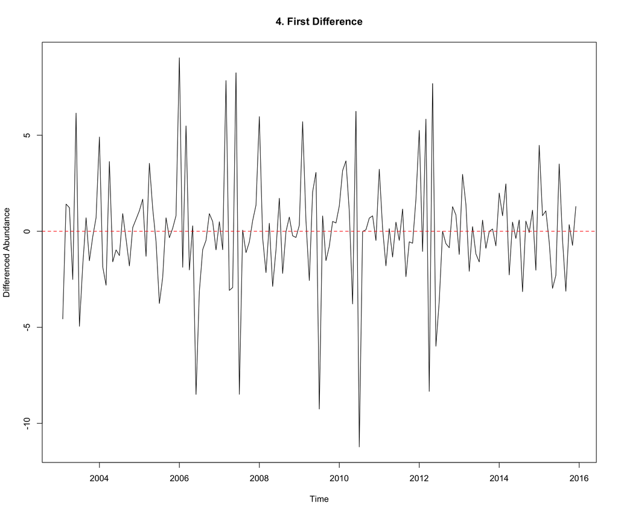

```r
# 4. First difference (removes trend)
diff_aphcan <- diff(aphcan)
plot(diff_aphcan, main="4. First Difference", ylab="Differenced Abundance")
abline(h=0, col="red", lty=2)
```

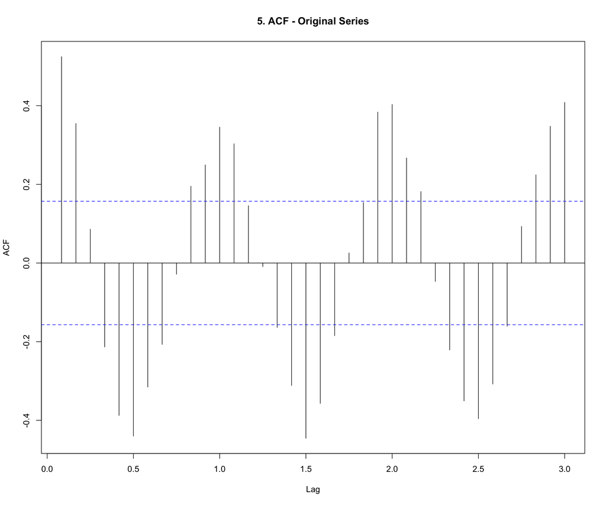

```r
# 5. ACF of original series
acf(aphcan, lag.max=36, main="5. ACF - Original Series")
```

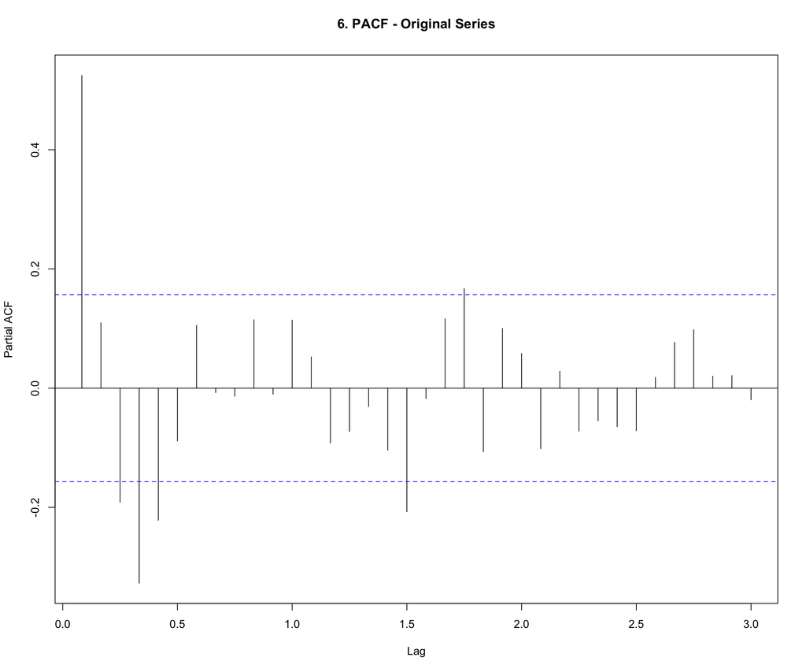

```r
# 6. PACF of original series
pacf(aphcan, lag.max=36, main="6. PACF - Original Series")
```

```r
par(mfrow=c(1,1))

# Augmented Dickey-Fuller test for stationarity
library(tseries)
adf_original <- adf.test(aphcan)
print("Augmented Dickey-Fuller Test (original series):")
```

```
## [1] "Augmented Dickey-Fuller Test (original series):"
```

```r
print(adf_original)
```

```
##
##  Augmented Dickey-Fuller Test
##
## data:  aphcan
## Dickey-Fuller = -7.4486, Lag order = 5, p-value = 0.01
## alternative hypothesis: stationary
```

```r
if(adf_original$p.value < 0.05) {
  print("→ Series is stationary (p < 0.05)")
} else {
  print("→ Series is non-stationary (p > 0.05) - differencing needed")
}
```

```
## [1] "→ Series is stationary (p < 0.05)"
```

```r
adf_diff <- adf.test(diff_aphcan)
print("Augmented Dickey-Fuller Test (differenced series):")
```

```
## [1] "Augmented Dickey-Fuller Test (differenced series):"
```

```r
print(adf_diff)
```

```
##
##  Augmented Dickey-Fuller Test
##
## data:  diff_aphcan
## Dickey-Fuller = -9.2009, Lag order = 5, p-value = 0.01
## alternative hypothesis: stationary
```

### How to Read ACF and PACF Plots

**INTERPRETING ACF AND PACF FOR ARIMA ORDER SELECTION**

ACF (Autocorrelation Function): - Shows correlation between series and its lagged values - Helps identify MA order (q)

PACF (Partial Autocorrelation Function):  
- Shows correlation after removing effects of intermediate lags - Helps identify AR order (p)

PATTERNS TO LOOK FOR:

For AR process (use PACF): - PACF cuts off sharply after lag p → suggests AR(p) - ACF decays gradually

For MA process (use ACF): - ACF cuts off sharply after lag q → suggests MA(q) - PACF decays gradually

For seasonal patterns: - Spikes at seasonal lags (12, 24, 36 for monthly data) - Suggests seasonal ARIMA component needed

Example interpretations: - PACF spike at lag 1 only → AR(1) - ACF spike at lag 1 only → MA(1) - Both decay gradually → ARMA model (both AR and MA) - Spikes at lag 12, 24 → Seasonal component needed

### Automatic ARIMA Selection

The `auto.arima()` function can help us select the best ARIMA model automatically:

```r
# Automatic ARIMA selection for Rayadito-Canelo
auto_aphcan <- auto.arima(aphcan, seasonal=TRUE, stepwise=FALSE, approximation=FALSE)
print("Automatically selected ARIMA model for Rayadito-Canelo:")
```

```
## [1] "Automatically selected ARIMA model for Rayadito-Canelo:"
```

```r
print(auto_aphcan)
```

```
## Series: aphcan
## ARIMA(2,0,2) with non-zero mean
##
## Coefficients:
##          ar1      ar2      ma1     ma2    mean
##       1.6505  -0.9096  -1.3163  0.6326  3.6082
## s.e.  0.0570   0.0548   0.1312  0.1063  0.2335
##
## sigma^2 = 5.832:  log likelihood = -356.97
## AIC=725.94   AICc=726.5   BIC=744.24
```

```r
# Automatic ARIMA selection for Rayadito-Notro
auto_aphnot <- auto.arima(aphnot, seasonal=TRUE, stepwise=FALSE, approximation=FALSE)
print("Automatically selected ARIMA model for Rayadito-Notro:")
```

```
## [1] "Automatically selected ARIMA model for Rayadito-Notro:"
```

```r
print(auto_aphnot)
```

```
## Series: aphnot
## ARIMA(0,0,1)(1,0,1)[12] with non-zero mean
##
## Coefficients:
##          ma1    sar1     sma1    mean
##       0.3357  0.8593  -0.6937  2.0677
## s.e.  0.0843  0.1215   0.1752  0.4705
##
## sigma^2 = 6.601:  log likelihood = -367.69
## AIC=745.38   AICc=745.78   BIC=760.63
```

```r
# Automatic ARIMA selection for Chincol-Canelo
auto_zoncan <- auto.arima(zoncan, seasonal=TRUE, stepwise=FALSE, approximation=FALSE)
print("Automatically selected ARIMA model for Chincol-Canelo:")
```

```
## [1] "Automatically selected ARIMA model for Chincol-Canelo:"
```

```r
print(auto_zoncan)
```

```
## Series: zoncan
## ARIMA(0,0,0)(1,0,0)[12] with non-zero mean
##
## Coefficients:
##         sar1    mean
##       0.4300  0.2871
## s.e.  0.0789  0.0872
##
## sigma^2 = 0.4349:  log likelihood = -156.63
## AIC=319.26   AICc=319.42   BIC=328.41
```

```r
# Automatic ARIMA selection for Chincol-Notro
auto_zonnot <- auto.arima(zonnot, seasonal=TRUE, stepwise=FALSE, approximation=FALSE)
print("Automatically selected ARIMA model for Chincol-Notro:")
```

```
## [1] "Automatically selected ARIMA model for Chincol-Notro:"
```

```r
print(auto_zonnot)
```

```
## Series: zonnot
## ARIMA(0,0,3)(1,0,1)[12] with non-zero mean
##
## Coefficients:
##          ma1      ma2     ma3    sar1     sma1    mean
##       0.0766  -0.0171  0.2530  0.7825  -0.4775  0.4112
## s.e.  0.0834   0.0710  0.0871  0.1332   0.2071  0.1362
##
## sigma^2 = 0.4284:  log likelihood = -153.9
## AIC=321.8   AICc=322.56   BIC=343.15
```

### Manual ARIMA Fitting

Below we will compare one species in two habitats as an example using ARIMA models of first order. ARIMA could be decomposed in AR-I-MA and 0 or 1 indicate if each component (autoregressive, integrated, or moving average) is present or not in the model.

```r
##Rayadito-Canelo
# ARIMA(1,1,1)(0,1,1)[12] means:
# Non-seasonal: AR(1), first differencing, MA(1)
# Seasonal: no seasonal AR, seasonal differencing, seasonal MA(1), period=12
m1.aphcan=arima(aphcan,order=c(1,1,1),seasonal=list(order=c(0,1,1), period=12))
print("Manual ARIMA model for Rayadito-Canelo:")
```

```
## [1] "Manual ARIMA model for Rayadito-Canelo:"
```

```r
print(m1.aphcan)
```

[output not shown]

```r
# Extract and interpret coefficients
print("Model coefficients:")
```

```
## [1] "Model coefficients:"
```

```r
print(m1.aphcan$coef)
```

```
##        ar1        ma1       sma1
##  0.3233413 -0.9926568 -0.9990041
```

```r
print(paste("AR(1) coefficient:", round(m1.aphcan$coef[1], 4)))
```

```
## [1] "AR(1) coefficient: 0.3233"
```

```r
print(paste("MA(1) coefficient:", round(m1.aphcan$coef[2], 4)))
```

```
## [1] "MA(1) coefficient: -0.9927"
```

```r
print(paste("Seasonal MA(1) coefficient:", round(m1.aphcan$coef[3], 4)))
```

```
## [1] "Seasonal MA(1) coefficient: -0.999"
```

```r
# AIC comparison
print(paste("Manual model AIC:", round(AIC(m1.aphcan), 2)))
```

```
## [1] "Manual model AIC: 685.22"
```

```r
print(paste("Auto model AIC:", round(AIC(auto_aphcan), 2)))
```

```
## [1] "Auto model AIC: 725.94"
```

```r
if(AIC(auto_aphcan) < AIC(m1.aphcan)) {
  print("→ Auto-selected model has better fit (lower AIC)")
} else {
  print("→ Manual model has better fit (lower AIC)")
}
```

```
## [1] "→ Manual model has better fit (lower AIC)"
```

### Comprehensive Model Diagnostics

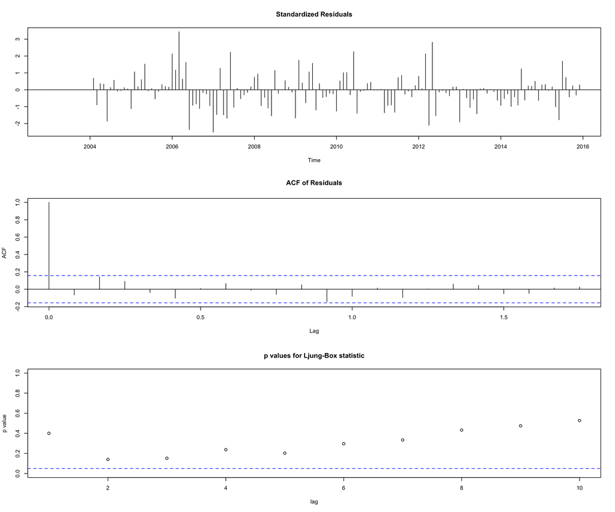

```r
##Rayadito-Canelo diagnostics

# 1. Standard diagnostic plots
tsdiag(m1.aphcan)
```

```r
# 2. Ljung-Box test for residual autocorrelation
box_test <- Box.test(m1.aphcan$residuals, lag=20, type="Ljung-Box")
print("Ljung-Box test (tests if residuals are white noise):")
```

```
## [1] "Ljung-Box test (tests if residuals are white noise):"
```

```r
print(box_test)
```

```
##
##  Box-Ljung test
##
## data:  m1.aphcan$residuals
## X-squared = 17.391, df = 20, p-value = 0.6275
```

```r
if(box_test$p.value > 0.05) {
  print("✓ Residuals appear to be white noise (p > 0.05) - Good!")
} else {
  print("✗ Residuals show autocorrelation (p < 0.05) - Model may need adjustment")
}
```

```
## [1] "✓ Residuals appear to be white noise (p > 0.05) - Good!"
```

```r
# 3. Test coefficient significance
coef_se <- sqrt(diag(m1.aphcan$var.coef))
z_values <- m1.aphcan$coef / coef_se
p_values <- (1-pnorm(abs(z_values)))*2

print("Coefficient significance tests:")
```

```
## [1] "Coefficient significance tests:"
```

```r
coef_table <- data.frame(
  Coefficient = names(m1.aphcan$coef),
  Estimate = round(m1.aphcan$coef, 4),
  Std_Error = round(coef_se, 4),
  Z_value = round(z_values, 4),
  P_value = round(p_values, 4),
  Significant = ifelse(p_values < 0.05, "Yes", "No")
)
print(coef_table)
```

```
##      Coefficient Estimate Std_Error Z_value P_value Significant
## ar1          ar1   0.3233    0.0851  3.7996  0.0001         Yes
## ma1          ma1  -0.9927    0.1312 -7.5641  0.0000         Yes
## sma1        sma1  -0.9990    0.3394 -2.9434  0.0032         Yes
```

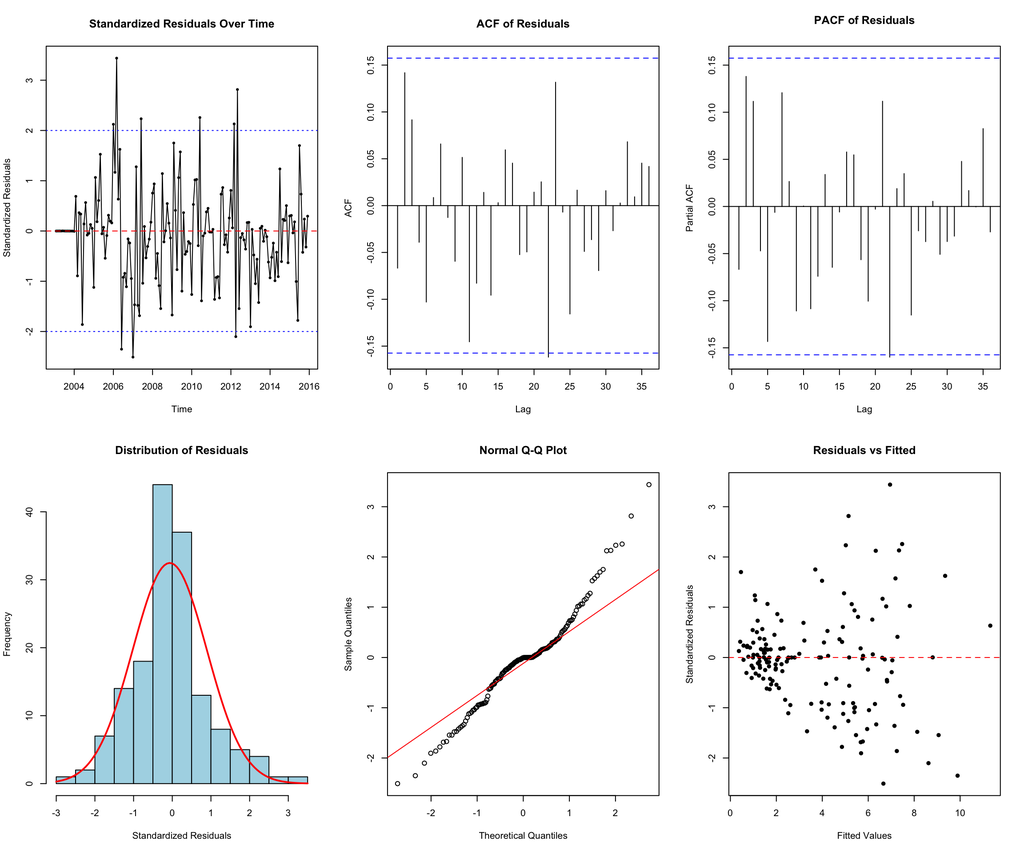

```r
# 4. Detailed residual analysis
residuals_std <- rstandard(m1.aphcan)

par(mfrow=c(2,3))

# Time series of standardized residuals
plot(window(residuals_std, start=c(2003,2)),
     ylab='Standardized Residuals',
     main='Standardized Residuals Over Time',
     type='o', pch=16)
abline(h=0, col="red", lty=2)
abline(h=c(-2, 2), col="blue", lty=3)

# ACF of residuals
acf(as.vector(window(residuals_std, start=c(2003,2))),
    lag.max=36,
    main="ACF of Residuals")

# PACF of residuals
pacf(as.vector(window(residuals_std, start=c(2003,2))),
     lag.max=36,
     main="PACF of Residuals")

# Histogram of residuals
hist(window(residuals_std, start=c(2003,2)),
     xlab='Standardized Residuals',
     main='Distribution of Residuals',
     col='lightblue', breaks=20)
curve(dnorm(x, mean=mean(residuals_std, na.rm=TRUE),
            sd=sd(residuals_std, na.rm=TRUE)) *
      length(residuals_std) * diff(hist(residuals_std, plot=FALSE)$breaks)[1],
      add=TRUE, col="red", lwd=2)

# Q-Q plot
qqnorm(residuals_std, main="Normal Q-Q Plot")
qqline(residuals_std, col="red")

# Residuals vs fitted
fitted_vals <- fitted(m1.aphcan)
residuals_to_plot <- as.vector(window(residuals_std, start=c(2003,2)))

# fitted() might return NULL for ARIMA, use an alternative approach
if(is.null(fitted_vals) || length(fitted_vals) == 0) {
  # Calculate fitted values as observed - residuals
  fitted_vals <- aphcan - residuals(m1.aphcan)
}

# Ensure same length
fitted_to_plot <- as.vector(window(fitted_vals, start=c(2003,2)))

# Make sure lengths match
min_length <- min(length(fitted_to_plot), length(residuals_to_plot))
fitted_to_plot <- fitted_to_plot[1:min_length]
residuals_to_plot <- residuals_to_plot[1:min_length]

plot(fitted_to_plot, residuals_to_plot,
     xlab="Fitted Values", ylab="Standardized Residuals",
     main="Residuals vs Fitted", pch=16)
abline(h=0, col="red", lty=2)
```

```r
par(mfrow=c(1,1))

# Shapiro-Wilk normality test
shapiro_test <- shapiro.test(as.vector(residuals_std))
print("Shapiro-Wilk normality test:")
```

```
## [1] "Shapiro-Wilk normality test:"
```

```r
print(shapiro_test)
```

```
##
##  Shapiro-Wilk normality test
##
## data:  as.vector(residuals_std)
## W = 0.96564, p-value = 0.000631
```

```r
if(shapiro_test$p.value > 0.05) {
  print("✓ Residuals are approximately normal (p > 0.05)")
} else {
  print("⚠ Residuals may not be normal (p < 0.05)")
}
```

```
## [1] "⚠ Residuals may not be normal (p < 0.05)"
```

### ARIMA Model for Rayadito-Notro

```r
##Rayadito-Notro
m1.aphnot=arima(aphnot,order=c(1,1,1),seasonal=list(order=c(0,1,1), period=12))
print("ARIMA model for Rayadito-Notro:")
```

```
## [1] "ARIMA model for Rayadito-Notro:"
```

```r
print(m1.aphnot)
```

[output not shown]

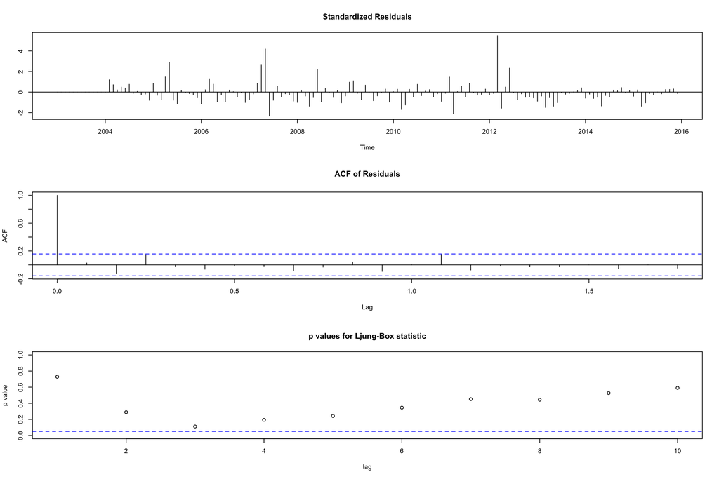

```r
# Diagnostics
tsdiag(m1.aphnot)
```

```r
# Box test
box_test_notro <- Box.test(m1.aphnot$residuals, lag=20, type="Ljung-Box")
print("Ljung-Box test:")
```

```
## [1] "Ljung-Box test:"
```

```r
print(box_test_notro)
```

```
##
##  Box-Ljung test
##
## data:  m1.aphnot$residuals
## X-squared = 15.567, df = 20, p-value = 0.7431
```

```r
# Coefficient significance
coef_se_notro <- sqrt(diag(m1.aphnot$var.coef))
z_values_notro <- m1.aphnot$coef / coef_se_notro
p_values_notro <- (1-pnorm(abs(z_values_notro)))*2

print("Coefficient significance:")
```

```
## [1] "Coefficient significance:"
```

```r
coef_table_notro <- data.frame(
  Coefficient = names(m1.aphnot$coef),
  Estimate = round(m1.aphnot$coef, 4),
  P_value = round(p_values_notro, 4),
  Significant = ifelse(p_values_notro < 0.05, "Yes", "No")
)
print(coef_table_notro)
```

```
##      Coefficient Estimate P_value Significant
## ar1          ar1   0.2302  0.0093         Yes
## ma1          ma1  -0.9569  0.0000         Yes
## sma1        sma1  -0.9093  0.0000         Yes
```

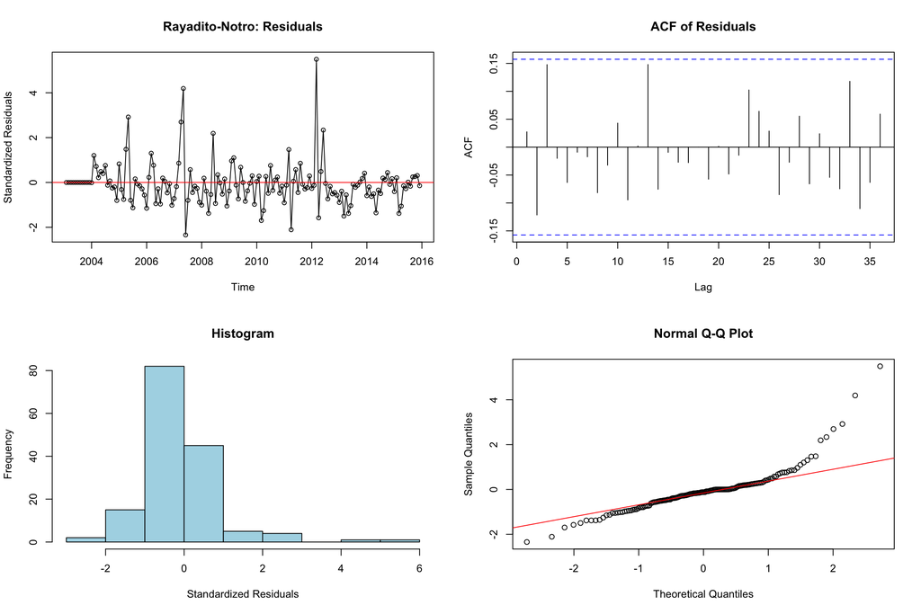

```r
# Residual plots
residuals_std_notro <- rstandard(m1.aphnot)
par(mfrow=c(2,2))
plot(window(residuals_std_notro, start=c(2003,2)),
     ylab='Standardized Residuals',
     main='Rayadito-Notro: Residuals',
     type='o')
abline(h=0, col="red")
acf(as.vector(window(residuals_std_notro, start=c(2003,2))),
    lag.max=36, main="ACF of Residuals")
hist(window(residuals_std_notro, start=c(2003,2)),
     xlab='Standardized Residuals', main='Histogram',
     col='lightblue')
qqnorm(residuals_std_notro)
qqline(residuals_std_notro, col="red")
```

```r
par(mfrow=c(1,1))
```

### Comparing Models: Manual vs Auto-selected

```r
# Compare manual and automatic models
comparison_table <- data.frame(
  Species_Habitat = c("Rayadito-Canelo", "Rayadito-Notro"),
  Manual_Model = c(
    paste0("ARIMA", paste(c(1,1,1), collapse=",")),
    paste0("ARIMA", paste(c(1,1,1), collapse=","))
  ),
  Manual_AIC = c(AIC(m1.aphcan), AIC(m1.aphnot)),
  Auto_Model = c(
    paste0("ARIMA",
           paste(auto_aphcan$arma[c(1,6,2,3,7,4,5)], collapse=",")),
    paste0("ARIMA",
           paste(auto_aphnot$arma[c(1,6,2,3,7,4,5)], collapse=","))
  ),
  Auto_AIC = c(AIC(auto_aphcan), AIC(auto_aphnot))
)
comparison_table$Best_Model <- ifelse(
  comparison_table$Auto_AIC < comparison_table$Manual_AIC,
  "Auto", "Manual"
)

print("Model Comparison Table:")
```

```
## [1] "Model Comparison Table:"
```

```r
print(comparison_table)
```

```
##   Species_Habitat Manual_Model Manual_AIC          Auto_Model Auto_AIC
## 1 Rayadito-Canelo   ARIMA1,1,1   685.2222 ARIMA2,0,2,0,0,0,12 725.9407
## 2  Rayadito-Notro   ARIMA1,1,1   707.3101 ARIMA0,0,1,1,0,1,12 745.3841
##   Best_Model
## 1     Manual
## 2     Manual
```

### Forecasting with ARIMA

One of the main applications of ARIMA is forecasting future values:

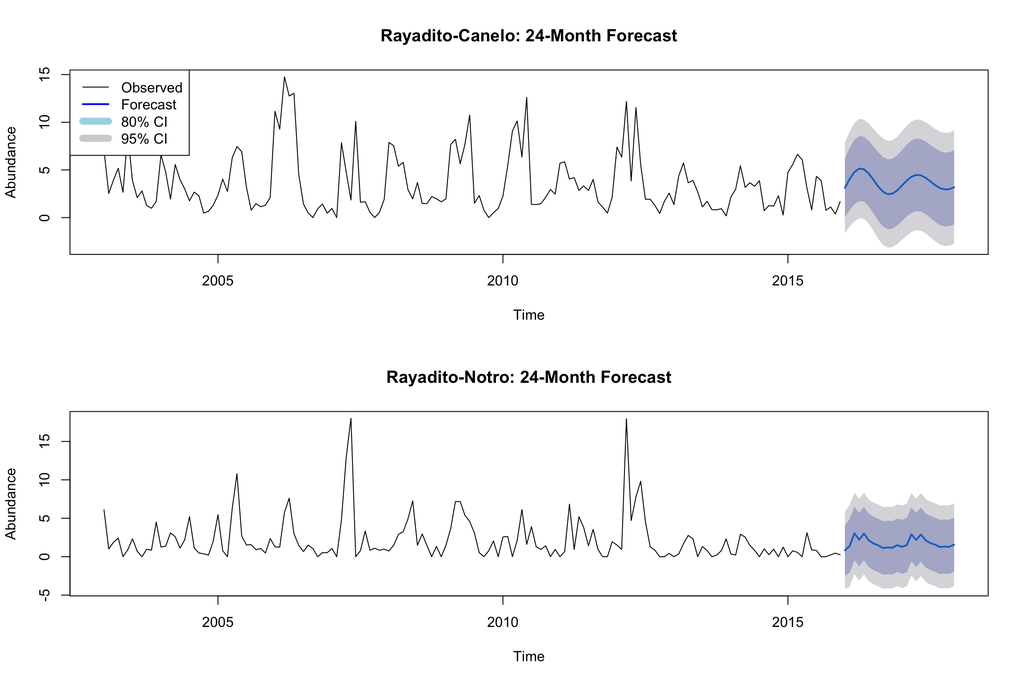

```r
# Forecast 24 months ahead using the automatic model
forecast_aphcan <- forecast(auto_aphcan, h=24)
forecast_aphnot <- forecast(auto_aphnot, h=24)

par(mfrow=c(2,1))

# Plot forecast for Rayadito-Canelo
plot(forecast_aphcan, main="Rayadito-Canelo: 24-Month Forecast",
     xlab="Time", ylab="Abundance")
legend("topleft",
       c("Observed", "Forecast", "80% CI", "95% CI"),
       col=c("black", "blue", "lightblue", "lightgray"),
       lty=c(1,1,1,1), lwd=c(1,2,8,8))

# Plot forecast for Rayadito-Notro
plot(forecast_aphnot, main="Rayadito-Notro: 24-Month Forecast",
     xlab="Time", ylab="Abundance")
```

```r
par(mfrow=c(1,1))

# Extract forecast values
print("Forecast summary for next 12 months (Rayadito-Canelo):")
```

```
## [1] "Forecast summary for next 12 months (Rayadito-Canelo):"
```

```r
print(head(as.data.frame(forecast_aphcan), 12))
```

```
##          Point Forecast       Lo 80    Hi 80       Lo 95     Hi 95
## Jan 2016       3.114643  0.01973302 6.209553 -1.61861335  7.847899
## Feb 2016       4.042549  0.77938639 7.305713 -0.94802780  9.033127
## Mar 2016       4.774007  1.40196910 8.146046 -0.38308011  9.931095
## Apr 2016       5.137260  1.73371328 8.540806 -0.06801535 10.342535
## May 2016       5.071485  1.66792287 8.475048 -0.13381432 10.276785
## Jun 2016       4.632526  1.20094993 8.064102 -0.61561657  9.880668
## Jul 2016       3.967865  0.46306827 7.472662 -1.39225907  9.327989
## Aug 2016       3.270130 -0.32002652 6.860286 -2.22054051  8.760800
## Sep 2016       2.723096 -0.92299489 6.369187 -2.85311895  8.299311
## Oct 2016       2.454873 -1.20724040 6.116987 -3.14584634  8.055593
## Nov 2016       2.509744 -1.15239574 6.171885 -3.09101563  8.110504
## Dec 2016       2.844273 -0.83308239 6.521629 -2.77975685  8.468303
```

```r
# Accuracy measures
accuracy_aphcan <- accuracy(auto_aphcan)
print("Model accuracy metrics (Rayadito-Canelo):")
```

```
## [1] "Model accuracy metrics (Rayadito-Canelo):"
```

```r
print(accuracy_aphcan)
```

```
##                      ME     RMSE      MAE MPE MAPE     MASE         ACF1
## Training set 0.00526167 2.375954 1.788455 NaN  Inf 0.744534 -0.002725951
```

### Comparing ARIMA Models Across Species

```r
# Fit automatic ARIMA for all species in Canelo habitat
species_list <- list(
  Rayadito = aphcan,
  Jilguero = carcan,
  Fiofio = elacan,
  Cometocino = phrcan,
  Chercan = trocan,
  Zorzal = turcan,
  Chincol = zoncan
)

# Fit models and store results
arima_results <- list()
for(sp_name in names(species_list)) {
  model <- auto.arima(species_list[[sp_name]], seasonal=TRUE)
  arima_results[[sp_name]] <- model
}

# Create summary table
summary_table <- data.frame(
  Species = names(arima_results),
  Model = sapply(arima_results, function(x) {
    paste0("(", paste(arimaorder(x)[1:3], collapse=","), ")",
           "(", paste(arimaorder(x)[4:6], collapse=","), ")[12]")
  }),
  AIC = sapply(arima_results, AIC),
  BIC = sapply(arima_results, BIC),
  LogLik = sapply(arima_results, logLik),
  Sigma2 = sapply(arima_results, function(x) x$sigma2)
)
summary_table <- summary_table[order(summary_table$AIC),]

print("ARIMA Model Summary for All Species (Canelo habitat):")
```

```
## [1] "ARIMA Model Summary for All Species (Canelo habitat):"
```

```r
print(summary_table)
```

```
##               Species                 Model      AIC      BIC     LogLik
## Zorzal         Zorzal (0,0,1)(NA,NA,NA)[12] 135.5760 144.7256  -64.78802
## Chercan       Chercan    (0,1,2)(2,0,1)[12] 286.6904 304.9509 -137.34518
## Chincol       Chincol    (0,0,0)(0,0,1)[12] 321.4577 330.6073 -157.72886
## Fiofio         Fiofio    (1,0,0)(0,1,2)[12] 412.4027 424.2820 -202.20136
## Jilguero     Jilguero    (1,0,0)(0,0,1)[12] 451.6146 463.8140 -221.80729
## Rayadito     Rayadito    (2,0,2)(0,0,1)[12] 731.2640 752.6130 -358.63198
## Cometocino Cometocino (2,0,0)(NA,NA,NA)[12] 790.1954 802.3948 -391.09770
##               Sigma2
## Zorzal     0.1360885
## Chercan    0.3448511
## Chincol    0.4413487
## Fiofio     0.9338027
## Jilguero   1.0218166
## Rayadito   6.0034895
## Cometocino 8.9725019
```

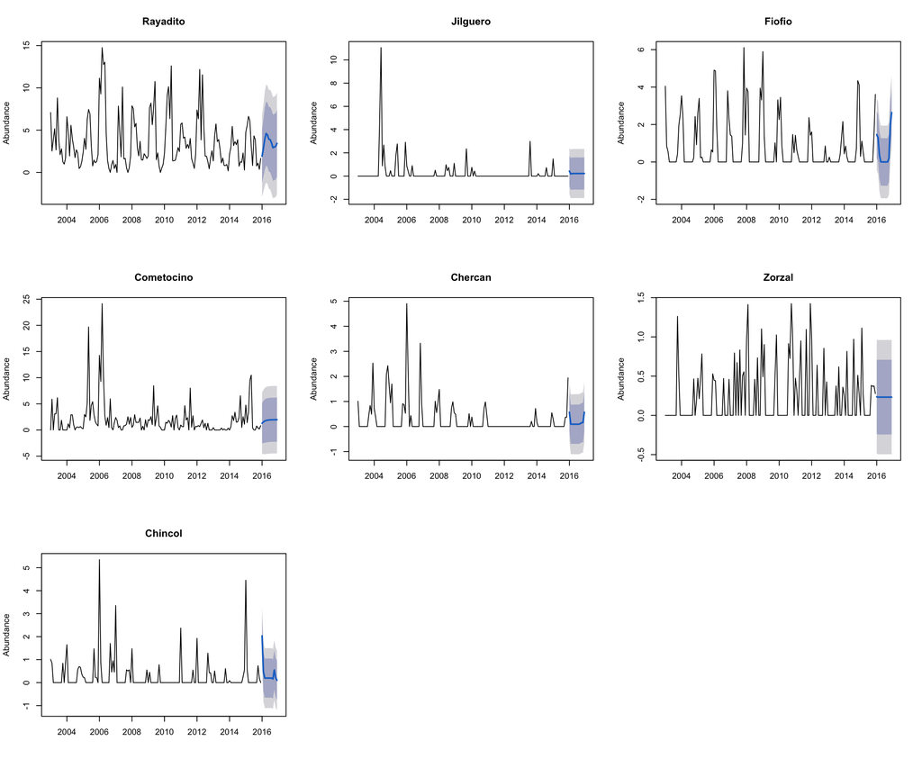

```r
# Visualize forecasts for all species
par(mfrow=c(3,3))
for(sp_name in names(arima_results)) {
  fc <- forecast(arima_results[[sp_name]], h=12)
  plot(fc, main=sp_name, xlab="", ylab="Abundance")
}
par(mfrow=c(1,1))
```

### Model Selection Criteria

**MODEL SELECTION AND INTERPRETATION GUIDE**

AIC (Akaike Information Criterion):

- Lower is better
- Penalizes model complexity
- Good for comparing multiple candidate models
- Difference < 2: Models essentially equivalent
- Difference 2-7: Considerable support for lower AIC
- Difference > 10: Strong preference for lower AIC

BIC (Bayesian Information Criterion):

- Lower is better
- Penalizes complexity more than AIC
- Preferred for large datasets
- More conservative (prefers simpler models)

Ljung-Box Test:

- Tests if residuals are white noise
- H0: Residuals are independent (good!)
- p > 0.05: Fail to reject H0 → Good model fit
- p < 0.05: Residuals still correlated → Poor fit

Residual Diagnostics Checklist:

✓ Residuals centered around zero

✓ Constant variance over time

✓ Approximately normally distributed

✓ No autocorrelation in residuals

✓ No obvious patterns or trends

If diagnostics fail: - Try different ARIMA orders

- Consider transformation (log, square root)
- Check for outliers
- Consider more complex seasonal patterns

### Practical Interpretation

The output of ARIMA models can be interpreted as follows:

Example interpretation of ARIMA(1,1,1)(0,1,1)[12] for Rayadito-Canelo:

**Non-seasonal components:**

- AR(1): Current abundance depends on previous month’s abundance
- I(1): One-time differencing removes linear trend
- MA(1): Incorporates previous month’s forecast error

**Seasonal components:**

- P=0: No direct seasonal autoregressive effect
- D=1: Seasonal differencing (compares to same month last year)
- Q=1: Seasonal moving average (accounts for seasonal forecast errors
- s=12: Seasonal period of 12 months (annual cycle)

**Biological interpretation:**

This model captures:

1. Month-to-month population dynamics (AR and MA)
2. Long-term population trends (differencing)
3. Annual seasonal cycles (seasonal component)

[figure not shown]

```r
# Extract fitted values and plot
fitted_values <- fitted(m1.aphcan)
par(mfrow=c(1,1))
plot(aphcan, main="Rayadito-Canelo: Observed vs Fitted",
     ylab="Abundance", col="black", lwd=1.5)
lines(fitted_values, col="red", lwd=1.5)
legend("topright", c("Observed", "Fitted"),
       col=c("black", "red"), lwd=2)
```

## Final thoughts

Time Series Analysis is a powerful tool to work with measurements repeated in time. Here I presented the tip of the iceberg, the most basic analyses, but there is a lot more that can be done in this subject. Usually, the main limitation is gathering a large dataset (at least 5 years of data) to make robust inferences from it. Of course the software will drop some results with a few points in time, but the interpretation of it may be wrong, so please take a note of caution on it: TSA with insufficient data may be misleading.

### Key Takeaways for ARIMA Modeling:

**Model Building Process:**

1. **Explore your data:** Plot time series, check for trends and seasonality
2. **Check stationarity:** Use ADF test, difference if needed
3. **Examine ACF/PACF:** Identify potential AR and MA orders
4. **Fit candidate models:** Try both manual specification and auto.arima()
5. **Check diagnostics:** Residuals should be white noise
6. **Compare models:** Use AIC/BIC for model selection
7. **Forecast:** Use best model for predictions
8. **Validate:** Check forecast accuracy with holdout data if possible

**Common Pitfalls to Avoid:**

- Don’t use ARIMA on non-stationary data without differencing
- Don’t ignore seasonal patterns in monthly/quarterly data
- Don’t trust models with autocorrelated residuals
- Don’t over-fit (too many parameters relative to data length)
- Don’t forget biological interpretation of model parameters

**Best Practices:**

- Always visualize your data first
- Start simple, add complexity only if needed
- Use automatic selection as a starting point
- Validate model assumptions thoroughly
- Consider multiple models and compare
- Interpret results in biological context
- Be cautious with long-term forecasts (uncertainty grows)

**Minimum Data Requirements:**

- At least 50-100 observations for reliable ARIMA
- At least 2 full seasonal cycles for seasonal ARIMA
- More data = more reliable parameter estimates
- Consider simpler methods if data is limited

**Further Resources:**

- “Time Series Analysis and Its Applications” by Shumway & Stoffer
- “Forecasting: Principles and Practice” by Hyndman & Athanasopoulos (free online)
- R packages: forecast, TSA, astsa, tseries

Licensing Creative Commons License

Licensed under a Creative Commons Attribution-ShareAlike 4.0 International License.  
2025 - Francisco E. Fontúrbel